# 計量経済学応用

回帰分析：交差項の利用と複合仮説の検定

矢内 勇生

2019-05-288

# 準備

今回使うパッケージを読み込む。インストール済みでなパッケージは、`install.packages()` でインストールしてから使う。

```r
library("tidyverse")
library("interplot")
```

Macユーザのみ次の行も実行。

```r
theme_set(theme_gray(base_size = 10, base_family = "HiraginoSans-W3"))
```

# 交差項の利用

浅野正彦・矢内勇生 (2018)『[Rによる計量政治学](https://github.com/yukiyanai/quant-methods-R)』第14章の内容に沿って説明する。

## データを手に入れる

浅野・矢内 (2018) で用いられているデータhr-data.RdsのCSV版 をダウンロードし、プロジェクト内のdataディレクトリに保存する。

```r
dir.create("data")
download.file(url = "https://raw.githubusercontent.com/yukiyanai/quant-methods-R/master/data/hr-data.csv",
              destfile = "data/hr-data.csv")
```

ダウンロードできたら、データを読み込む。

```r
HR <- read_csv("data/hr-data.csv")
```

データの中身を確認する。

```r
glimpse(HR)
```

```
## Observations: 8,803
## Variables: 22
## $ year       <dbl> 1996, 1996, 1996, 1996, 1996, 1996, 1996, 1996, 1996,…
## $ ku         <chr> "aichi", "aichi", "aichi", "aichi", "aichi", "aichi",…
## $ kun        <dbl> 1, 1, 1, 1, 1, 1, 1, 2, 2, 2, 2, 2, 2, 2, 2, 3, 3, 3,…
## $ status     <chr> "現職", "元職", "現職", "新人", "新人", "新人", "新人", "現職", "元職",…
## $ name       <chr> "KAWAMURA, TAKASHI", "IMAEDA, NORIO", "SATO, TAISUKE"…
## $ party      <chr> "NFP", "LDP", "DPJ", "JCP", "others", "kokuminto", "i…
## $ party_code <dbl> 8, 1, 3, 2, 100, 22, 99, 8, 1, 3, 2, 10, 100, 99, 22,…
## $ previous   <dbl> 2, 3, 2, 0, 0, 0, 0, 1, 1, 0, 0, 0, 0, 0, 0, 1, 3, 1,…
## $ wl         <chr> "当選", "落選", "落選", "落選", "落選", "落選", "落選", "当選", "落選",…
## $ voteshare  <dbl> 40.0, 25.7, 20.1, 13.3, 0.4, 0.3, 0.2, 32.9, 26.4, 25…
## $ age        <dbl> 47, 72, 53, 43, 51, 51, 45, 51, 71, 30, 31, 44, 61, 4…
## $ nocand     <dbl> 7, 7, 7, 7, 7, 7, 7, 8, 8, 8, 8, 8, 8, 8, 8, 7, 7, 7,…
## $ rank       <dbl> 1, 2, 3, 4, 5, 6, 7, 1, 2, 3, 4, 5, 6, 7, 8, 1, 2, 3,…
## $ vote       <dbl> 66876, 42969, 33503, 22209, 616, 566, 312, 56101, 449…
## $ eligible   <dbl> 346774, 346774, 346774, 346774, 346774, 346774, 34677…
## $ turnout    <dbl> 49.2, 49.2, 49.2, 49.2, 49.2, 49.2, 49.2, 51.8, 51.8,…
## $ exp        <dbl> 9828097, 9311555, 9231284, 2177203, NA, NA, NA, 12940…
## $ expm       <dbl> 9.828097, 9.311555, 9.231284, 2.177203, NA, NA, NA, 1…
## $ vs         <dbl> 0.400, 0.257, 0.201, 0.133, 0.004, 0.003, 0.002, 0.32…
## $ exppv      <dbl> 28.341505, 26.851941, 26.620462, 6.278449, NA, NA, NA…
## $ smd        <chr> "当選", "落選", "落選", "落選", "落選", "落選", "落選", "当選", "落選",…
## $ party_jpn  <chr> "新進党", "自民党", "民主党", "共産党", "その他", "国民党", "無所属", "新進党…
```

2005年の衆院選について、voteshare, exppv, eligibleの3変数だけ残す。`select()` という名前の関数は、**dplyr**パッケージ (**tidyverse**で読み込んだ) と **interplot** パッケージの両者に含まれるので、`dplyr::select()` と書いて、dplyrの`select()` を使う。

```r
HR05 <- HR %>%
  filter(year == 2005) %>%
  dplyr::select(voteshare, exppv, eligible)
```

## 記述統計

2005年の衆院選データについて、上で選んだ3変数の基本的な統計量を確認する。

```r
summary(HR05)
```

```
##    voteshare         exppv           eligible
##  Min.   : 0.60   Min.   : 0.148   Min.   :214235
##  1st Qu.: 8.80   1st Qu.: 8.352   1st Qu.:297385
##  Median :34.80   Median :22.837   Median :347866
##  Mean   :30.33   Mean   :24.627   Mean   :344654
##  3rd Qu.:46.60   3rd Qu.:35.269   3rd Qu.:397210
##  Max.   :73.60   Max.   :89.332   Max.   :465181
##                  NA's   :4
```

exppv に欠測値が4つあることがわかる。

3変数の標準偏差を求める。

```r
apply(HR05, MARGIN = 2, FUN = sd, na.rm = TRUE)
```

```
##   voteshare       exppv    eligible
##    19.23023    17.90740 63898.23016
```

得票率 voteshare と 一人当たり選挙費用 exppv の関係を、散布図で確認する。

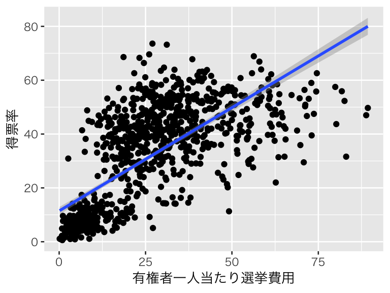

```r
plt_vs_ex <- ggplot(HR05, aes(x = exppv, y = voteshare)) +
  geom_point() +
  geom_smooth(method = "lm") +
  labs(x = "有権者一人当たり選挙費用", y = "得票率")
plot(plt_vs_ex)
```

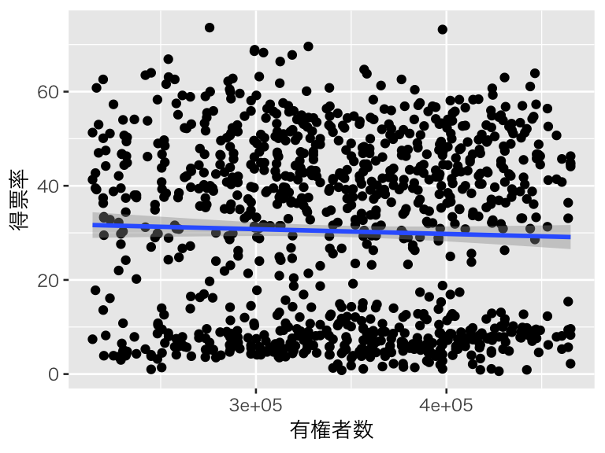

```r
plt_vs_el <- ggplot(HR05, aes(x = eligible, y = voteshare)) +
  geom_point() +
  geom_smooth(method = "lm") +
  labs(x = "有権者数", y = "得票率")
plot(plt_vs_el)
```

## 交差項を使った回帰分析

有権者一人あたり選挙費用 exppv が得票率 voteshare に与える影響は、有権者数 eligible によって変わるだろうか。これを確かめるために、exppv と eligible の交差項 (interaction term) を回帰分析に投入し、以下のモデルを推定する。

$$得票率_i = \beta_0 + \beta_1 選挙費用_i + \beta_2 有権者数_i + \beta_3 選挙費用_i \times 有権者数_i + 誤差$$

このモデルを`lm()で推定するためには、次のコードを使う。

```r
model_1 <- lm(voteshare ~ exppv * eligible, data = HR05)
```

つまり、`変数1 * 変数2` という書き方をすると、重回帰分析に 変数1、変数2、変数1と変数2の交差項という3つの項が加えられる。

結果を確認してみよう。

```r
summary(model_1)
```

```
##
## Call:
## lm(formula = voteshare ~ exppv * eligible, data = HR05)
##
## Residuals:
##     Min      1Q  Median      3Q     Max
## -43.290  -8.158  -3.295   8.472  44.886
##
## Coefficients:
##                  Estimate Std. Error t value Pr(>|t|)
## (Intercept)     9.638e+00  3.793e+00   2.541   0.0112
## exppv           1.917e-02  1.140e-01   0.168   0.8665
## eligible       -1.483e-06  1.073e-05  -0.138   0.8901
## exppv:eligible  2.549e-06  3.497e-07   7.289 6.44e-13
##
## Residual standard error: 12.58 on 981 degrees of freedom
##   (4 observations deleted due to missingness)
## Multiple R-squared:  0.572,  Adjusted R-squared:  0.5707
## F-statistic:   437 on 3 and 981 DF,  p-value: < 2.2e-16
```

この結果は、どのように解釈できるだろうか。例えば、exppv の係数の推定値 0.0192 はどういう意味を持っているだおるか。通常の回帰分析と同様に考えると、**他の変数の値を一定に保ったとき、** exppvが1単位増えると、得票率が0.0192 ポイント上がるという意味である。

しかし、**他の変数を一定に保つ**ことは可能だろうか？このモデルでは、特殊な状況を除き、それは不可能である。exppv の値を変えれば、exppv $\times$ eligibleの値も変わってしまうからである。、**他の変数を一定に保つ**ことができるのは、eligble = 0 のときだけある。しかし、有権者数がゼロの選挙区は存在しないので、0.0192という数字をそのまま解釈することはできない。

この例からわかる通り、交差項を含む回帰分析の結果を、表から読み取ることは一般的に非常に難しい。これは、表を提示するだけでは、分析結果の報告として不十分だということを意味する。

先ほどのモデルでは説明変数をそのまま使っていた。次に、説明変数を中心化して、同様のモデルを推定してみよう。

```r
HR05 <- HR05 %>%
  mutate(exppv_c = exppv - mean(exppv, na.rm = TRUE),
         eligible_c = eligible - mean(eligible))
model_2 <- lm(voteshare ~ exppv_c * eligible_c, data = HR05)
summary(model_2)
```

```
##
## Call:
## lm(formula = voteshare ~ exppv_c * eligible_c, data = HR05)
##
## Residuals:
##     Min      1Q  Median      3Q     Max
## -43.290  -8.158  -3.295   8.472  44.886
##
## Coefficients:
##                     Estimate Std. Error t value Pr(>|t|)
## (Intercept)        3.123e+01  4.187e-01  74.595  < 2e-16
## exppv_c            8.977e-01  2.514e-02  35.702  < 2e-16
## eligible_c         6.129e-05  6.576e-06   9.320  < 2e-16
## exppv_c:eligible_c 2.549e-06  3.497e-07   7.289 6.44e-13
##
## Residual standard error: 12.58 on 981 degrees of freedom
##   (4 observations deleted due to missingness)
## Multiple R-squared:  0.572,  Adjusted R-squared:  0.5707
## F-statistic:   437 on 3 and 981 DF,  p-value: < 2.2e-16
```

この結果は、どのように解釈できるだろうか。例えば、exppv の係数の推定値 0.8977 はどういう意味を持っているだおるか。通常の回帰分析と同様に考えると、**他の変数の値を一定に保ったとき、** exppv_cが1単位増えると、得票率が0.8977 ポイント上がるという意味である。

では、**他の変数を一定に保つ**ことは可能だろうか？このモデルでも、特殊な状況を除き、それは不可能である。exppv_c の値を変えれば、exppv_c $\times$ eligible_c の値も変わってしまうからである。、**他の変数を一定に保つ**ことができるのは、eligble_c = 0 のときだけある。eligible_c は有権者数 eligible を中心化した変数なので、eligble_c = 0というのは、「有権者数が平均値のとき」という意味である。したがって、「有権者数が平均値のとき」という特殊な場合に限り、0.8977 という数字の意味を解釈することができる。

このように、説明変数を中心化することにより、少しだけ結果が解釈しやすくなった。しかし、有権者数が平気値のとき以外については、解釈が不可能である。よって、もう少し工夫が必要である。そのような工夫の一つが、図を使った方法である。